# Midterm Decision

### Analysis

I have used the final exam and midterm scores from a previous semester of Math 425 to determine if I should drop my midterm score basing my final exam entirely on my final or if I should keep my midterm and receive a weighted average of my midterm and final score for the final exam. Having a 98 on the midterm, my final exam score is predicted to be 113; however, in reality it is not possible to get over a 100 on the exam. Using the following model, I have decided to keep my midterm score and average it with my final score.

$$\overbrace{\hat{Y}_i}^{\text{Final Exam}} = {-63.7889} + {1.8079}\overbrace{X_1i}^{\text{Midterm}}+{58.8332}\overbrace{X_2i}^{\text{Gender}} + {-0.8525}\overbrace{{X_1i}{X_2i}}^{\text{Interaction}}$$

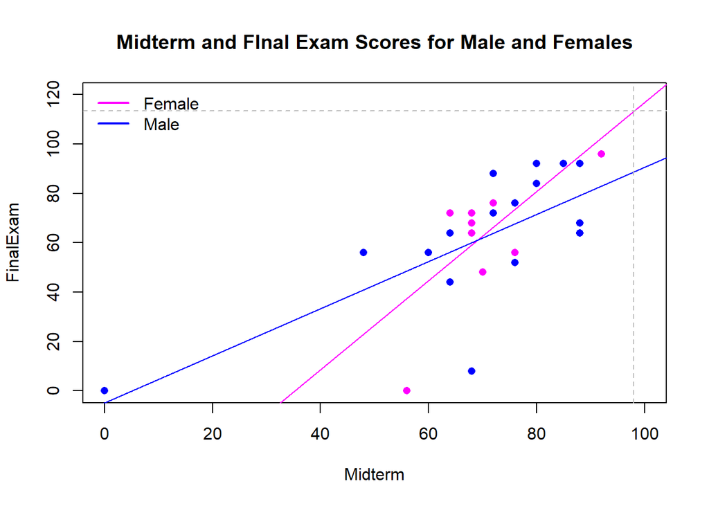

```r
midterm <- midterms # %>% filter(Midterm > 0)
midterm.lm <- lm(FinalExam ~ Midterm + Gender + Midterm:Gender, data=midterm)
palette(c("magenta", "blue"))
plot(FinalExam ~ Midterm, data=midterm, col=factor(Gender), pch =16, main="Midterm and FInal Exam Scores for Male and Females", xlim=c(0,100), ylim=c(0,120))
legend("topleft", lty = c(1,1,0), legend = c("Female", "Male"), bty='n', col=c("magenta", "blue"), lwd=2)
b <- coef(midterm.lm)
abline(b[1], b[2], col="magenta")
abline(b[1] + b[3],b[2] +b[4],col="blue")
mypreds <- predict(midterm.lm, data.frame(Midterm=98, Gender="Female"))
abline(h=mypreds, v=98, lty=2, col="gray")
```

```r
predict(midterm.lm, data.frame(Midterm=98, Gender="Female"))
```

```
##        1
## 113.3818
```

### Technical Details

The full regression model for my linear regression:
$${Y_i} = {\beta_0} + {\beta_1}{X_1i} + {\beta_2}{X_2i} + {\beta_3}{X_1i}{X_2i} + \epsilon_i$$

The null and alternative hypotheses for this linear regression are as follows

$$H_0: \beta_0 = \beta_1 = \beta_2 = \beta_3 = 0$$

$$H_a: \beta_i \neq 0 \ \text{for at least one}\ i \in \{0,1,\ldots,p\}$$

with a significance level of

$$\alpha = 0.05$$

##### Results of the Linear Regression

```r
(summary(midterm.lm))
```

```
##
## Call:
## lm(formula = FinalExam ~ Midterm + Gender + Midterm:Gender, data = midterm)
##
## Residuals:
##     Min      1Q  Median      3Q     Max
## -52.010 -12.188   7.812  12.883  24.169
##
## Coefficients:
##                    Estimate Std. Error t value Pr(>|t|)
## (Intercept)        -63.7889    52.6881  -1.211   0.2373
## Midterm              1.8079     0.7487   2.415   0.0234 *
## GenderMale          58.8332    54.4221   1.081   0.2900
## Midterm:GenderMale  -0.8525     0.7741  -1.101   0.2813
## ---
## Signif. codes:  0 '***' 0.001 '**' 0.01 '*' 0.05 '.' 0.1 ' ' 1
##
## Residual standard error: 21.22 on 25 degrees of freedom
## Multiple R-squared:  0.5442, Adjusted R-squared:  0.4895
## F-statistic:  9.95 on 3 and 25 DF,  p-value: 0.0001694
```

The p-value for this regression is significant: 0.0001694. There is sufficient evidence to say that $\beta_i \neq 0$ for at least one $\ i \in \{0,1,\ldots,p\}$. The R-squared value is 0.5442. The regression is not the greatest fit for the data.

##### Diagnostic Plots

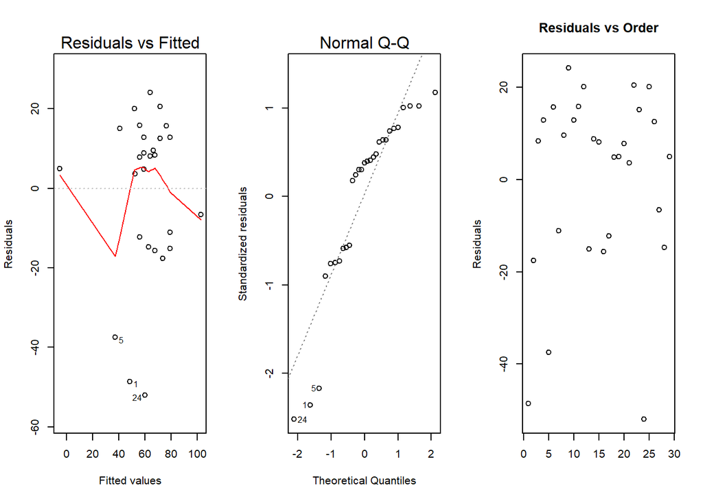

```r
par(mfrow=c(1,3))
plot(midterm.lm, which=1:2)
plot(midterm.lm$residuals, main="Residuals vs Order", xlab="", ylab="Residuals")
```

According to the boxCox, a Y-transformation is not needed for this regression.

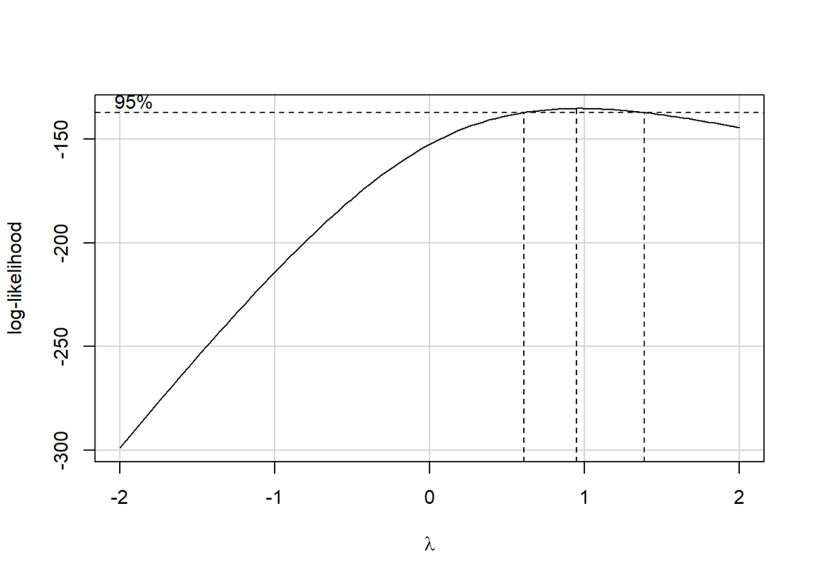

```r
midterm1.lm <- lm((FinalExam + 1) ~ Midterm + Gender + Midterm:Gender, data=midterm)
boxCox(midterm1.lm)
```